# analyse

Mathias Thomasen Madsen

1/1/2022

```r
library(tidyverse)
```

Before we can analyse the data, we have to import the data from windows to rstudios. I created a new directory solely for analysing, to protect the original datasheet. I Created a folder in the directory named Data where i imported the datasheet through the desktop.

Now i import the datasheet into rstudios and name i data.

```r
data<-read.csv("Data/police_killings.csv")
```

```r
data %>%
  mean(Age)
```

```
## [1] NA
```

Therefore to be able to work with the datasheet i need to remove all the NA’s in the Age column.I used this youtube videoer to find na.omit() could help https://www.google.com/search?q=remove+na+from+column&sxsrf=AOaemvLeFO1zKhl2aColc8VHcD5hjJWsfw%3A1641070175863&ei=X77QYdvhM8eXxc8PhZ--gAc&ved=0ahUKEwibjYjntpH1AhXHS_EDHYWPD3AQ4dUDCA8&uact=5&oq=remove+na+from+column&gs_lcp=Cgdnd3Mtd2l6EAMyBAgjECcyBQgAEMsBMgUIABDLATIFCAAQywEyBQgAEMsBMgUIABDLATIGCAAQFhAeMgYIABAWEB4yBggAEBYQHjIGCAAQFhAeOgcIABBHELADSgQIQRgASgQIRhgAUOUXWMQhYLEjaANwAngAgAFyiAHrBJIBAzEuNZgBAKABAcgBCMABAQ&sclient=gws-wiz#kpvalbx=_Z77QYdqANtKVxc8P6qaPoA418

```r
data_no_na<-data %>%
  na.omit(Age)
```

na.omit() removes all NA’s from the datasheet, but since there were only added NA’s to the Age column, those were removed. therefore you can see the variables have shrinked from 5430 to 5181. I first tried out with a datasheet were i had added NA’s to all empty cells, but using na.omit() with that datasheet would significantly shrink the variables, so i decided to do what I’ve shown here.

```r
data_no_na %>%
  mean()
```

```
## [1] NA
```

I wanna calculate the percentage of how each race is represented in the datasheet. https://stackoverflow.com/questions/42379751/how-do-i-find-the-percentage-of-something-in-r/42379897

```r
library(dplyr)
```

```r
data %>%
  group_by(Race) %>%
  summarise(percent=100*n()/nrow(data))
```

```
## # A tibble: 11 x 2
##    Race  percent
##    <chr>   <dbl>
##  1 ""    12.8
##  2 "A"    1.60
##  3 "B"   23.2
##  4 "H"   15.8
##  5 "I"    0.0552
##  6 "L"    0.442
##  7 "M"    0.0184
##  8 "N"    1.38
##  9 "O"    0.884
## 10 "PI"   0.0184
## 11 "W"   43.8
```

Using these numbers, we can calculate how big a percentage of the killed were white.

```r
100-12.83609576-1.60220994-23.18600368-15.76427256-0.05524862-0.44198895-0.01841621-1.38121547-0.88397790-0.01841621
```

```
## [1] 43.81215
```

So, 43.81% were white, 23.19 were black, 15.76 were hispanic and 0.44 were latino. It can be assumed that potentially latinos and hispanics are defined as the same catagory. Thereby we now know the races most representated

I’m mostly interested in working with the larger Groups, which are whites, blacks and hispanics. Therefore i calculated the percentage these races represents. I also did this to make sure i calculated the right percentage whites represents. The filter by race line i got from adelas script

```r
data %>%
  filter(Race %in% c("B", "W", "H")) %>%
  group_by(Race) %>%
  summarise(percent=100*n()/nrow(data))
```

```
## # A tibble: 3 x 2
##   Race  percent
##   <chr>   <dbl>
## 1 B        23.2
## 2 H        15.8
## 3 W        43.8
```

Luckily we get the same results as before.

I want to make a graf that shows this coherence.

```r
library(ggplot2)
library(ggridges)
```

Used Adelas script to understand how to make a column graph.

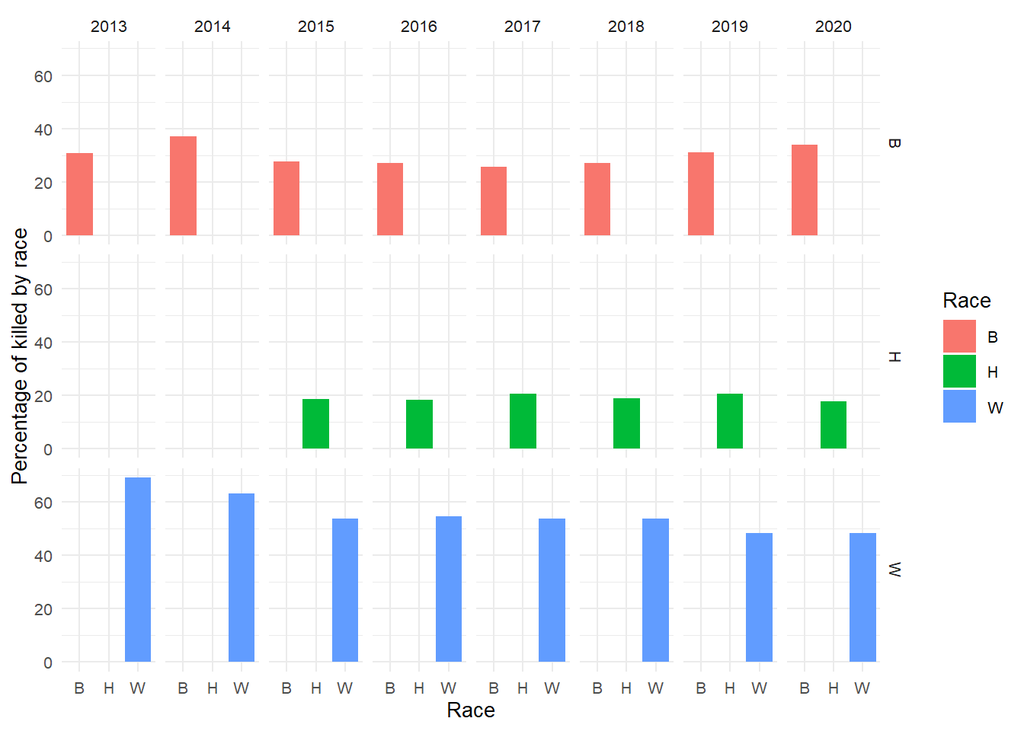

```r
data_no_na %>%
  filter(Race %in% c("W", "B", "H")) %>%
  group_by(Year,Race) %>%
  tally() %>%
  mutate(perc = n / sum(n) * 100)  %>%
  ggplot(aes(Race,
             perc,
             fill = Race)) +
  geom_col() +
  facet_grid(Race~Year) +
  theme_minimal(base_size = 10) +
  xlab("Race") +
  ylab("Percentage of killed by race")
```

It is interesting that Hispanics arent representated in 2013 and 2014. My thought is that Latinos and Hispanics are used as synonyms. Therefore i made another similar graph showing Latinos instead of Hispanics

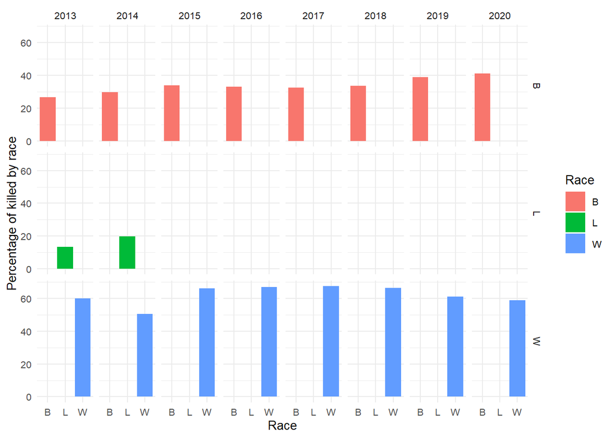

```r
data_no_na %>%
  filter(Race %in% c("W", "B", "L")) %>%
  group_by(Year,Race) %>%
  tally() %>%
  mutate(perc = n / sum(n) * 100)  %>%
  ggplot(aes(Race,
             perc,
             fill = Race)) +
  geom_col() +
  facet_grid(Race~Year) +
  theme_minimal(base_size = 10) +
  xlab("Race") +
  ylab("Percentage of killed by race")
```

My thesis seems to prove correct Therefore i should apply hispanics to the latino race class to get a better graph.

```r
write_csv(data,"policekillings2.csv")
```

I used openrefine to change the variable “H” to “L”. I used the facet/text facet. There i edited the “H” to “L”.

```r
data_ny<-read.csv("data/policekillings2.csv")
```

Whenever i try and edit “H” to “L” in the spreadsheet either manually in excel or thorugh openrefine, it corrupts the rest of the data 2015-2020. So it doesn’t seem posible to make a tidier spreadsheet this way.

```r
data %>%
  filter(Race %in% c("L", "H")) %>%
  group_by(Race) %>%
  summarise(percent=100*n()/nrow(data))
```

```
## # A tibble: 2 x 2
##   Race  percent
##   <chr>   <dbl>
## 1 H      15.8
## 2 L       0.442
```

The amount of latinos killed in percentage are therefore 16.21%

```r
15.764273+0.441989
```

```
## [1] 16.20626
```

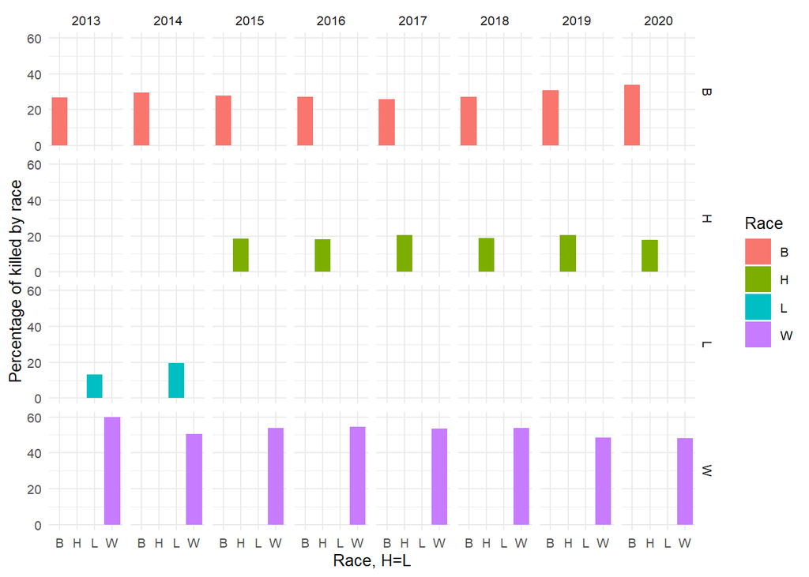

```r
data_no_na %>%
  filter(Race %in% c("W", "B", "L","H")) %>%
  group_by(Year,Race) %>%
  tally() %>%
  mutate(perc = n / sum(n) * 100)  %>%
  ggplot(aes(Race,
             perc,
             fill = Race)) +
  geom_col() +
  facet_grid(Race~Year) +
  theme_minimal(base_size = 10) +
  xlab("Race, H=L") +
  ylab("Percentage of killed by race")
```

Here “H” represents “L” too

Now, i want to compare this to how this correlates to the population.

I collected data from the United States Census Bureau https://www.census.gov/quickfacts/fact/table/US/PST045221 It says that White = 60.1% Black=13.4% Latino=18.5%

The numbers often vary because it’s a gray zone whatever race people feel like that they relate to.

I will now calculate how the percentage killed based on race correlates to the population

White

```r
60.1-43.81215
```

```
## [1] 16.28785
```

```r
(16.28785/43.81215)*100
```

```
## [1] 37.17656
```

Black

```r
23.18600-13.4
```

```
## [1] 9.786
```

```r
(9.786/13.4)*100
```

```
## [1] 73.02985
```

The black population is over represented by 73.0%

Latino

```r
18.5-16.20626
```

```
## [1] 2.29374
```

```r
(2.29374/18.5)*100
```

```
## [1] 12.39859
```

The latino population is under represented by 12.4%